# Homework 4 | Solutions

Solutions to Homework 4

Omer Yalcin  
2022-04-19

## Question 1

```r
data("house.selling.price.2")
# object name too long, rename
house <- house.selling.price.2
rm(house.selling.price.2)

# also rename the variables to make them more intuitive

names(house) <- c('Price', 'Size', 'Beds', 'Baths', 'New')
```

### A

The variable $\textrm{Beds}$ would be deleted first in backward elimination, because its p-value 0.487 is the largest of all the variables.

### B

```r
# Write a function that, for any given variable name, regresses that variable on Price (P) and gives the p-value:

get_p_value <- function(variable) {
  variable %>%
    paste0("Price ~ ", .) %>%
    as.formula() %>%
    lm(data = house) %>%
    summary() %>%
    use_series('coefficients') %>%
    extract(variable,'Pr(>|t|)') %>%
    return()
}

# apply the function to all potential explanatory variables
sapply(names(house)[-1], get_p_value)
```

```
        Size         Beds        Baths          New
2.346660e-34 4.758795e-10 9.839165e-16 4.514570e-04
```

Size has the lowest p-value when regressed against Price, so it should be the first variable to be added in forward selection.

The correlation matrix given in the question gives us the same information: out of all the candidates, Size has the highest correlation with Price: 0.899.

### C

Once other variables are controlled for, most of the explanation done by Beds is instead done by other variables. For example, houses with more beds are also larger in size. When Beds is the only explanatory variable, the model attributes the effect of the Size variable to Beds. However, once Size is also in the model and thus controlled for, the p-value of Beds gets larger as it doesn’t really have much explanatory power when it comes to variation in Price that remains unexplained after accounting for Size.

### D

As the book shows in pp 420 - 423 (which is why I won’t include here), for this dataset, backward elimination, forward selection, and stepwise regression all point to the same model: the model that only excludes ‘Beds.’ So, let’s compare the model that has Beds to the one that doesn’t.

```r
fit_full <- lm(Price ~ ., data = house)
fit_nobeds <- lm(Price ~ . -Beds, data = house)
```

Now, let’s write functions to gather each metric that we want to use:

```r
rsq <- function(fit) summary(fit)$r.squared
adj_rsq <- function(fit) summary(fit)$adj.r.squared
PRESS <- function(fit) {
    pr <- residuals(fit)/(1 - lm.influence(fit)$hat)
    sum(pr^2)
}
# the functions for AIC and BIC are already AIC() and BIC()
```

Apply the two functions to the two objects:

```r
models <- list(fit_full, fit_nobeds)
data.frame(models = c('fit_full', 'fit_nobeds'),
           rsq = sapply(models, rsq),
           adj.rsq = sapply(models, adj_rsq),
           PRESS = sapply(models, PRESS),
           AIC = sapply(models, AIC),
           BIC = sapply(models, BIC)
) %>%
  print()
```

```
      models       rsq   adj.rsq    PRESS      AIC      BIC
1   fit_full 0.8688630 0.8629022 28390.22 790.6225 805.8181
2 fit_nobeds 0.8681361 0.8636912 27860.05 789.1366 801.7996
```

Note that, for R-squares and Adjusted R-squared, larger is “better” while for PRESS, AIC, and BIC, lower is “better.” However, because R-squared always increases with the addition of new variables, it’s not very important for our purposes here. With other metrics, the model without Beds is the better model since it has higher adjusted R-squared, lower PRESS, AIC, and BIC.

### E

Thus I select the model without the Beds variable.

## Question 2

```r
data(trees)
```

### A

```r
tree_model <- lm(Volume ~ Girth + Height, data = trees)
summary(tree_model)
```

```
Call:
lm(formula = Volume ~ Girth + Height, data = trees)

Residuals:
    Min      1Q  Median      3Q     Max
-6.4065 -2.6493 -0.2876  2.2003  8.4847

Coefficients:
            Estimate Std. Error t value Pr(>|t|)
(Intercept) -57.9877     8.6382  -6.713 2.75e-07 ***
Girth         4.7082     0.2643  17.816  < 2e-16 ***
Height        0.3393     0.1302   2.607   0.0145 *
---
Signif. codes:  0 '***' 0.001 '**' 0.01 '*' 0.05 '.' 0.1 ' ' 1

Residual standard error: 3.882 on 28 degrees of freedom
Multiple R-squared:  0.948, Adjusted R-squared:  0.9442
F-statistic:   255 on 2 and 28 DF,  p-value: < 2.2e-16
```

### B

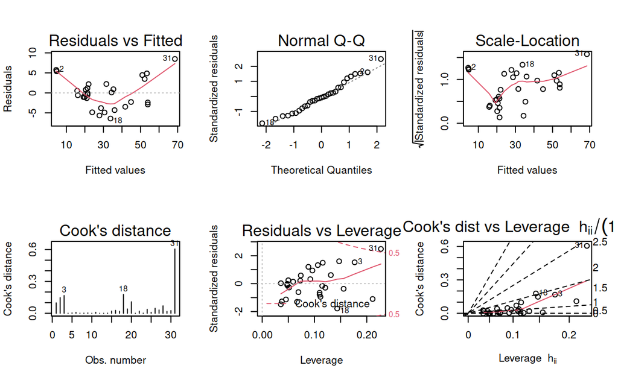

```r
par(mfrow = c(2,3))
plot(tree_model, which = 1:6)
```

The most obvious violation, based on the first plot, is the violation of the linearity assumption. The red line in the fitted values vs residuals plot should be somewhat straight, but it is actually U-shaped. The main reason for this is that volume is related to $\textrm{diameter}^2$, but we use the diameter itself in the model (Girth). Let’s see if using a quadratic term fixes the issue.

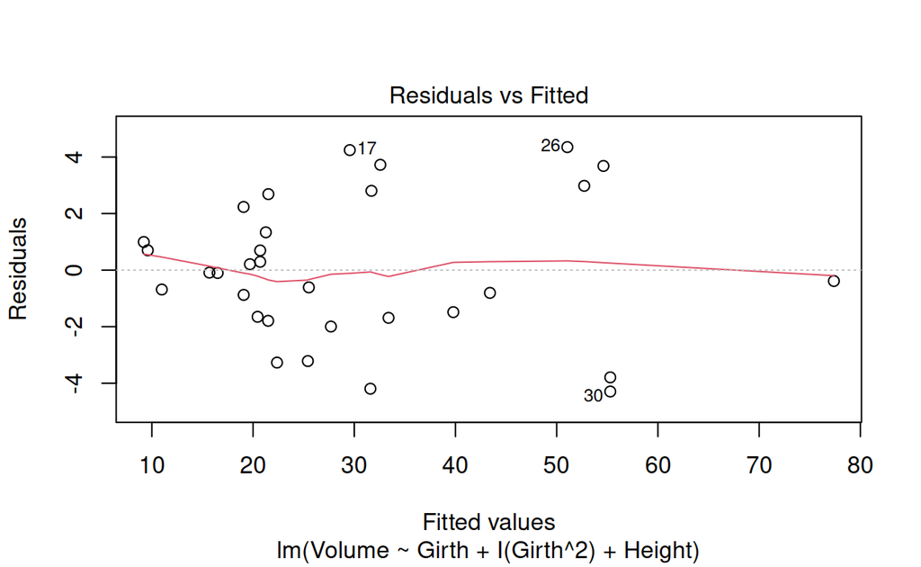

```r
tree_model_quad <- lm(Volume ~ Girth + I(Girth^2) + Height, data = trees)
plot(tree_model_quad, which = 1)
```

The line is much more straight now.

## Question 3

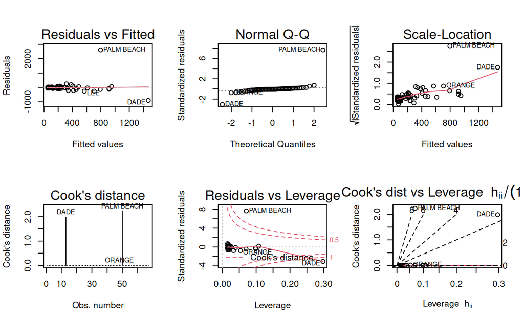

```r
data("florida")
florida_model <- lm(Buchanan ~ Bush, data = florida)
par(mfrow = c(2,3))
plot(florida_model, which = 1:6)
```

In this model, Palm Beach County is a massive outlier. If we were to fit a better model (and really, the correct model) where each variable is logged (as the book suggests but omitted in this homework), Palm Beach County would be somewhat less of an outlier but would still stand out. Let’s see:

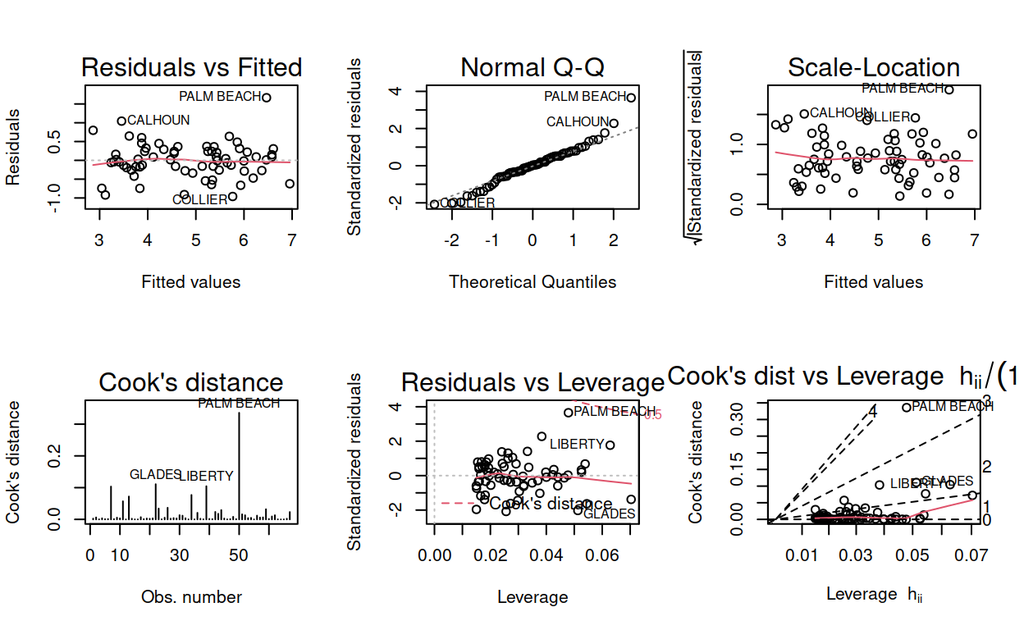

```r
data("florida")
florida_model_logged <- lm(log(Buchanan) ~ log(Bush), data = florida)
par(mfrow = c(2,3))
plot(florida_model_logged, which = 1:6)
```